# pilots_explore2

# 1 Description:

What changed:

- Added color to the board background.
- Added patterned outline.
- The board is smaller now 500x500 px.
- The board is randomly positioned within a 700x700 arena.
- The prompt picture appears separately on a screen, instead of appearing below the board. Thus, participants can’t use that image and text as landmarks.

## 1.1 Exact vs rough accuracy

Rough accuracy is 1 city-block distance away from the correct cell.

People struccle in schema-IC condition. Images change location after every session. Are we ok with performance being so low for each session?

No clear difference at the new-PA learning stage between schema-C and schema-IC

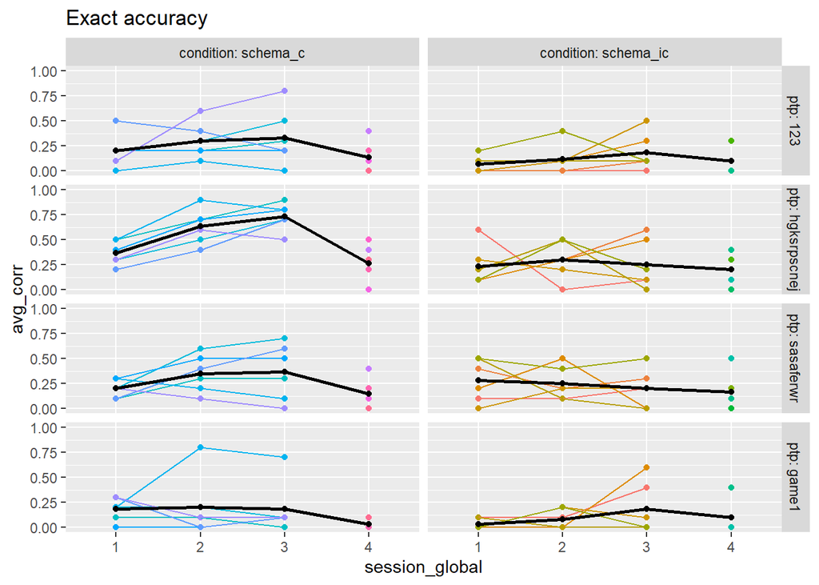

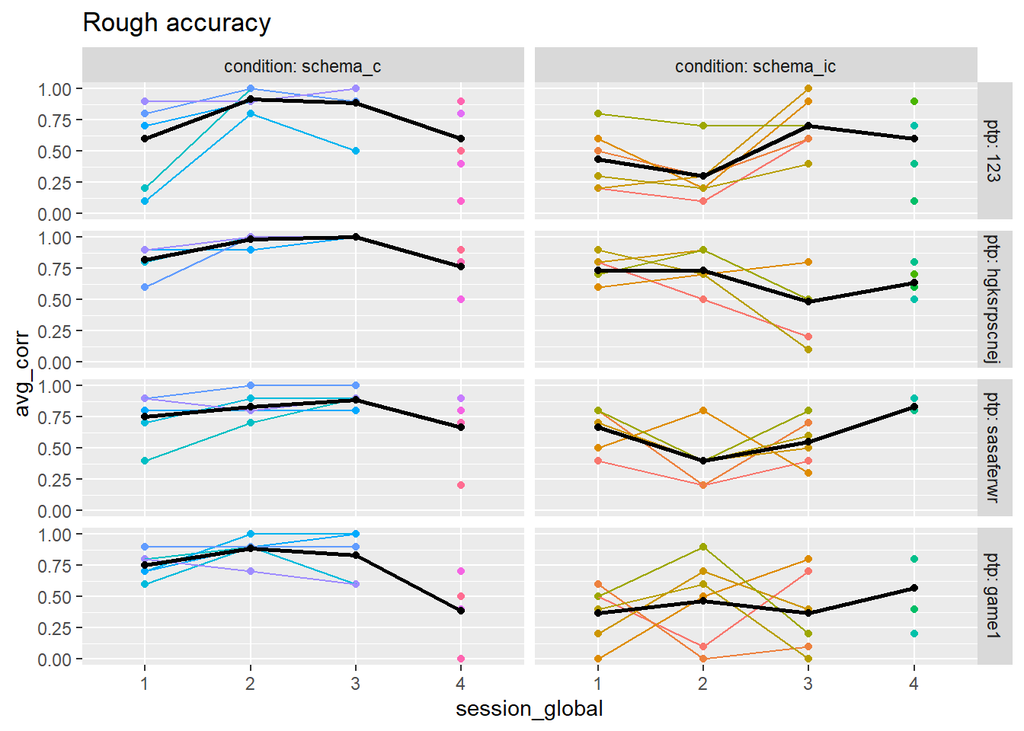

## 1.2 Multiple radii

I also coded accuracy as a function of radius around the target location. The targets are about 42x42px on the screen. So I’ve taken radii in steps of 21 pixels.

See this screenshot to get a sense of the size of the various radii.

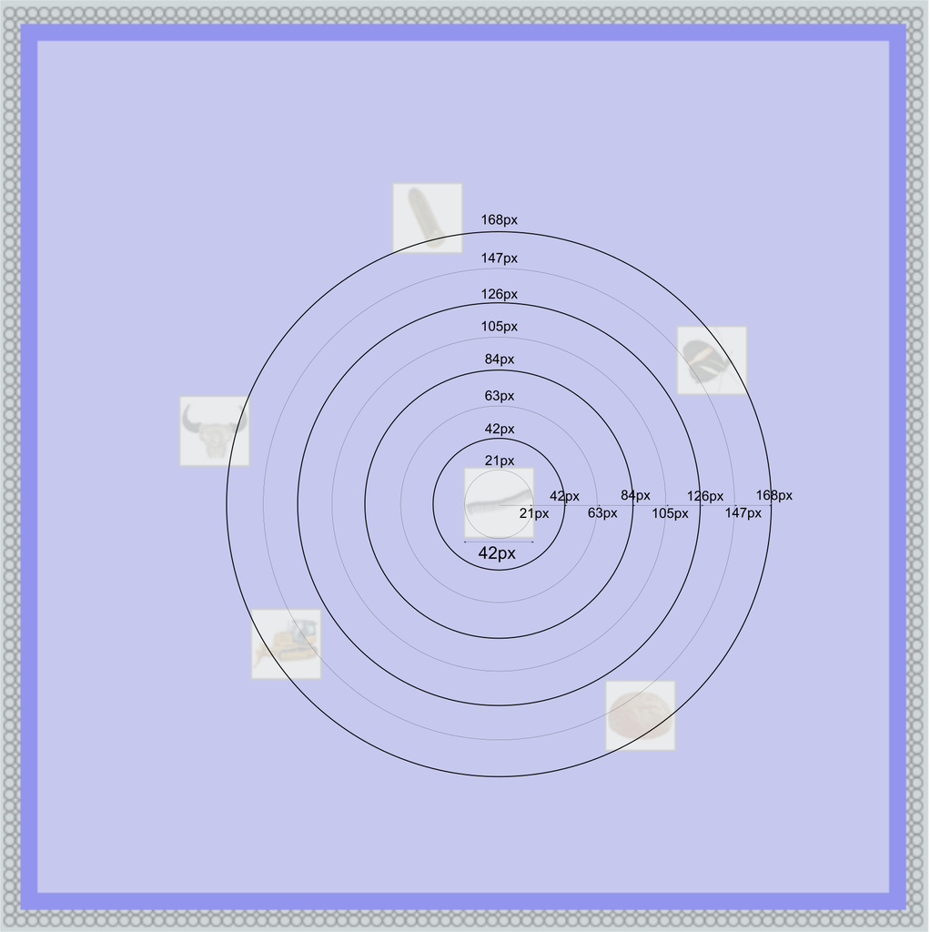

### 1.2.1 Plot descriptions:

Below are 4 plots: 2 for schema-C and 2 for schema-IC.

In all plots, rows are participants.

In the 1st and 3rd plots, columns are sessions, with 4th session being new PA learning. Here, X axes are various accuracy types.

In the 2nd and 4th plots, columns are accuracies measured with different radii. Here, X axes are sessions

From the data, seems like radius of 63 might be a good one.

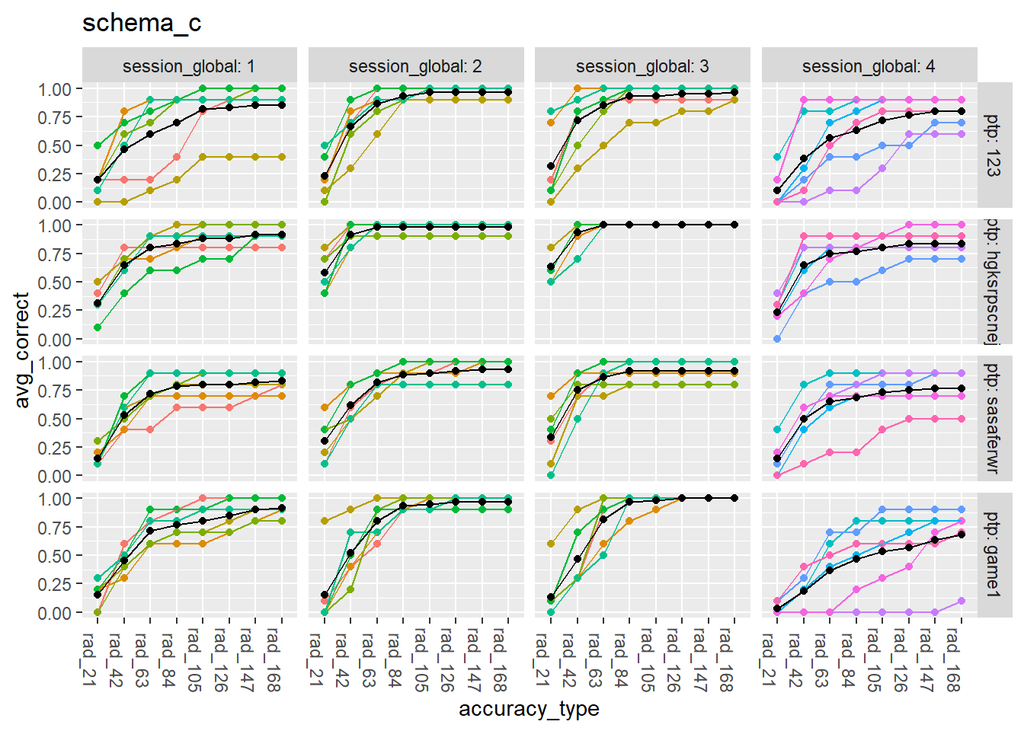

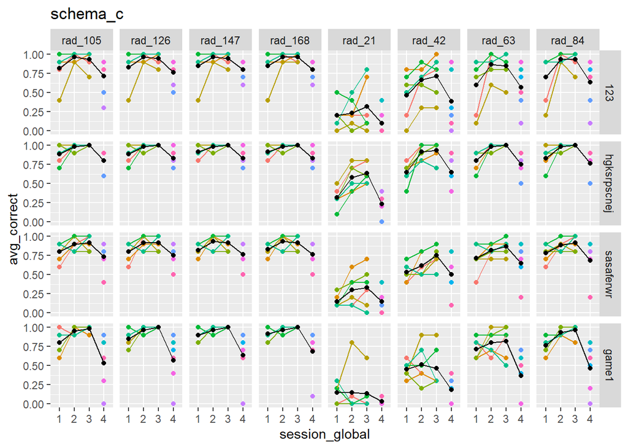

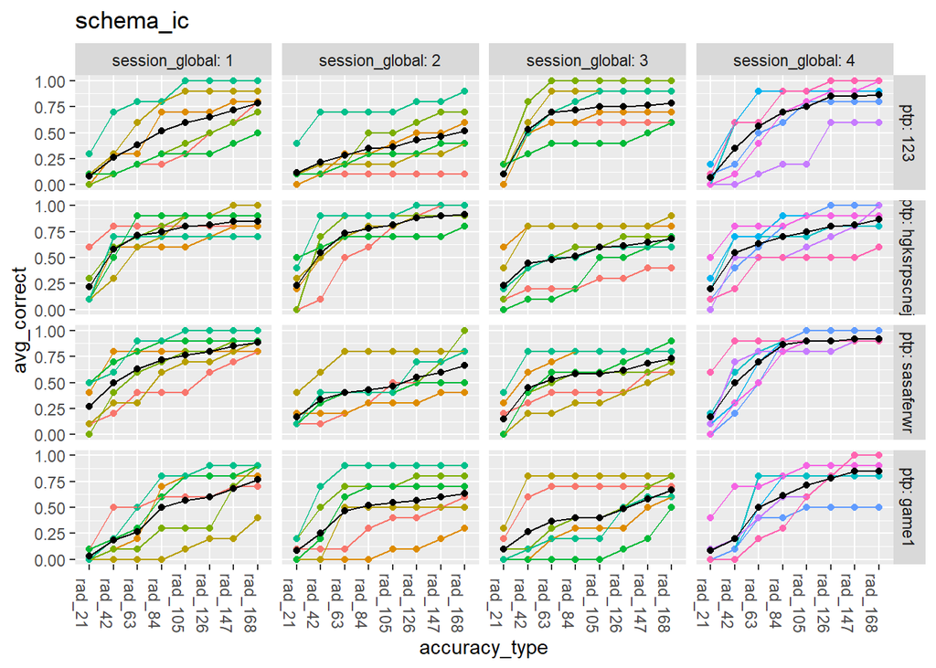

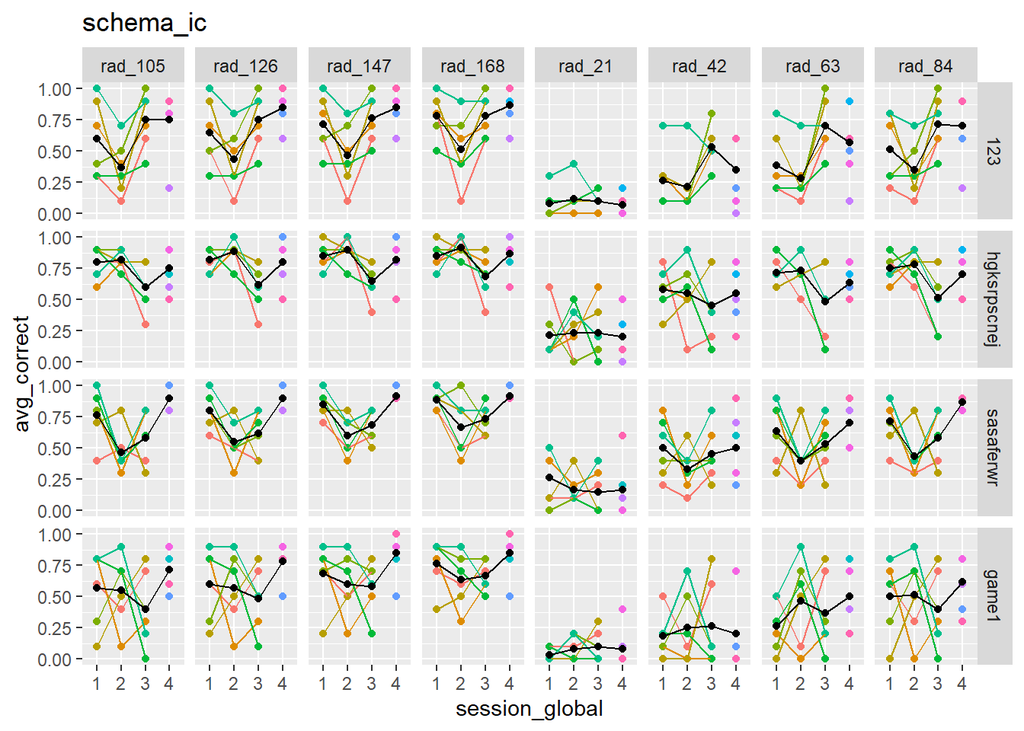